# KC and PR scRNA-seq import of filtered 10x output and QC of placental villous tissue

```r
# Function to convert from 10x output to seurat object with no filtering
tenx_to_seu <- function(tenx_directory, name) {
  seu <- CreateSeuratObject(
    counts = Read10X(tenx_directory),
    project = name)
  return(seu)
}
```

## Unfiltered 10x output stats

Unfiltered 10x output data have been stored as dgCMatrix. Vector is all caps represent final columns for supplemental table. Chunk contains TOTAL.DROPLETS.RAW, TOTAL.RNA.RAW, TOTAL.GENES.RAW, FETAL.SEX.

```r
# Get raw 10X data directory
tenx.raw.out <- paste0(here("data", "tenx_unfiltered_data"), "/")
# Get filenames
names.raw <-
  grep(
    dir(
      path = tenx.raw.out             #list all files, unfortunately includes .ini files
      ),
    pattern = "(kc|tnl)",        #pattern to search for, excludes .ini files
    value = T                    #return matches
    )
# Get files
files <-
  paste0(
    tenx.raw.out,
    names.raw
  )
# Read files into R
raw.list <- lapply(files, function(x) readRDS(x))
# Rename according to naming convention
LIBRARY.ID <- c("1A", "1B", "2A", "2B", "3", "4", "5")
names(raw.list) <- LIBRARY.ID
# Create a Seurat object out of each file
raw.seurat <- lapply(raw.list, function(x) CreateSeuratObject(counts = x))
# Clean-up memory
rm(raw.list)

# Get number of total droplets sequenced (always 737280)
TOTAL.DROPLETS.RAW <- lapply(raw.seurat, function(x) x %>% ncol()) %>% as.numeric
# Total unique RNA molecules
TOTAL.RNA.RAW <- lapply(raw.seurat, function(x) x$nCount_RNA %>% sum()) %>% as.numeric
# Total unique genes measured
TOTAL.GENES.RAW <- lapply(raw.seurat, function(x) x %>% nrow()) %>% as.numeric
# Sex of samples
FETAL.SEX <- c("F", "F", "M", "M", "M", "F", "M")
```

## Get list of Seurat objects

Contains TOTAL.CELLS

```r
tenx_out <- paste0(here("data", "tenx_outs"), "/")
# Pull full file paths
names <-
  grep(
    dir(
      path = tenx_out             #list all files, unfortunately includes .ini files
      ),
    pattern = "(kc|pr)(.\\d+)+", #pattern to search for, excludes .ini files
    value = T                    #return matches
    )
files <-
  paste0(
    tenx_out,
    names
  )

# Create list of Seurat objects
counts <- map2(files, names, tenx_to_seu)
# Name list
names(counts) <- names
# Manually add batch metadata to distinguish kc from pr
counts$kc.40.1$'batch' <- "kc"
counts$kc.40.2$'batch' <- "kc"
counts$kc.42.1$'batch' <- "kc"
counts$kc.42.2$'batch' <- "kc"
counts$pr.478$'batch' <- "pr"
counts$pr.481$'batch' <- "pr"
counts$pr.484$'batch' <- "pr"
# Manually add bioreplicate metadata
counts$kc.40.1$'biorep' <- "kc.40"
counts$kc.40.2$'biorep' <- "kc.40"
counts$kc.42.1$'biorep' <- "kc.42"
counts$kc.42.2$'biorep' <- "kc.42"
counts$pr.478$'biorep' <- "pr.478"
counts$pr.481$'biorep' <- "pr.481"
counts$pr.484$'biorep' <- "pr.484"

TOTAL.CELLS <- lapply(counts, function(x) ncol(x)) %>% as.numeric()
```

## Create list of freemuxlet raw output data

```r
freemux_dir <- paste0(here("data", "freemuxlet", "raw_data"), "/")
names <-
  grep(
    dir(
      path = freemux_dir             #list all files, unfortunately includes .ini files
      ),
    pattern = "(kc|pr)(_\\d+)+", #pattern to search for, excludes .ini files
    value = T                    #return matches
    )
files <-
  paste0(
    freemux_dir,
    names
  )
# Read in freemuxlet dataframes, specifying the datatype in each column
freemux.clusters <- lapply(files, readr::read_tsv, col_types = "iciiffdfddddfdfddfdd")
names(freemux.clusters) <- names

# Optional 'QC' freemux output?
```

## Custom function to add freemuxlet cluster assignment to Seurat MetaData

```r
# Add freemuxlet cluster assignment to Seurat Metadata
AddFreemuxletMetaData <- function(seu, freemux.data, col.name) {
  seu.barcodes <- tibble (
    BARCODE = rownames(seu@meta.data)) # get barcodes list from Seurat object
  join <- left_join(                      # join freemuxlet assignment with barcodes
    seu.barcodes,
    freemux.data %>%
      dplyr::select(BARCODE, BEST.GUESS) %>%
      mutate(
        BEST.GUESS = fct_recode(          # Refactor freemuxlet assignments
          BEST.GUESS,
          "1" = "1,1",
          "0" = "0,0",
          "doublet" = "1,0"
        )
      )
  )
  seu <- AddMetaData(seu,                 # Add MetaData to Seurat object
                     join %>% pull(BEST.GUESS),
                     col.name = col.name)
  return(seu)                             # Return augmented Seurat object
}
```

## Add freemuxlet cluster assignment to Seurat objects

Error output for pr.478 because it is the only dataset with no assigned doublets. Output appears normal otherwise

```r
mapped <-
  map2(counts,                              # List of Seurat objects
       freemux.clusters,                    # List of freemuxlet raw data
       AddFreemuxletMetaData,               # Function to call
       col.name = "freemuxlet.assignments") # Every metadata column has same name
rm(counts)       # Remove data
rm(freemux.clusters) # Remove data
```

## Merge Seurat objects and remove doublets

Chunk contains FETAL.MATERNAL.DOUBLETS.REMOVED

```r
# Merge, adding cell id information because barcodes can and have been duplicated across experiments
kc.seu <- merge(x = mapped[[1]],                # Seurat object
             y = mapped[(2:4)],                  # List
             add.cell.ids = names(mapped)[1:4])   # Add cell IDs using names

# Identify number of cells removed for doublets
doublets.kc <-
  kc.seu@meta.data %>%
  mutate(doublet = as.factor(freemuxlet.assignments)) %>%
  group_by(orig.ident, doublet) %>%
  tally() %>%
  filter(doublet == "doublet") %>%
  dplyr::select(n)
doublets.kc <- doublets.kc$n

# Remove doublets
kc.seu <- subset(x = kc.seu,
              subset = freemuxlet.assignments == "doublet",
              invert = T)

# Merge, adding cell id information because barcodes can and have been duplicated across experiments
pr.seu <- merge(x = mapped[[5]],                # Seurat object
             y = mapped[(6:7)],             # List
             add.cell.ids = names(mapped)[5:7])   # Add cell IDs using names

# Identify number of cells removed for doublets
doublets.pr <-
  pr.seu@meta.data %>%
  mutate(doublet = as.factor(freemuxlet.assignments)) %>%
  group_by(orig.ident, doublet) %>%
  tally() %>%
  filter(doublet == "doublet") %>%
  dplyr::select(n)
doublets.pr <- c(0, doublets.pr$n)

pr.seu <- subset(x = pr.seu,
              subset = freemuxlet.assignments == "doublet",
              invert = T)

FETAL.MATERNAL.DOUBLETS.REMOVED <- c(doublets.kc, doublets.pr)
```

# KC QC

```r
# Convert to SingleCellExperiment for QC
sce <- as.SingleCellExperiment(kc.seu)
# Factorize the batch variable
sce$batch <- as.factor(sce$batch)
```

## Droplet Calling

Skipping droplet calling since 10x already filters that under Cell Ranger 4.0 based on Aaron Lun’s EmptyDroplets().

## Calculate QC Metrics

Increased NMADs to 4 because NMAD of 3.0 looks too restrictive for KC data. Looks like an appropriate compromise based on QC plots.

```r
# Find mitochondrial genes
is.mito <- grepl("^MT-", rownames(sce))
# Add per cell QC metrics to the object
sce <- addPerCellQC(sce, subsets = list(Mito=is.mito))

# Create QC data frame
qc.df <- perCellQCMetrics(sce, subsets = list(Mito=is.mito))
# Reasons for exclusion, considering batch
batch.reasons <- quickPerCellQC(qc.df, batch=sce$batch,
                                sub.fields = "subsets_Mito_percent",
                                nmads = 4)
colSums(as.matrix(batch.reasons))
```

```
##              low_lib_size            low_n_features high_subsets_Mito_percent
##                       112                       280                       638
##                   discard
##                       700
```

```r
# Add discard metadata to object
sce$discard <- batch.reasons$discard
discard <- batch.reasons$discard
```

QC plots.

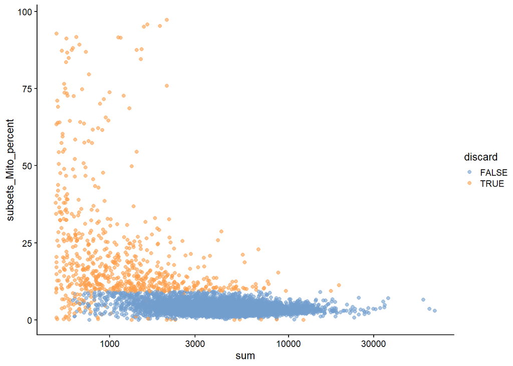

```r
plotColData(sce, x="sum", y="subsets_Mito_percent", colour_by = "discard") + scale_x_log10()
```

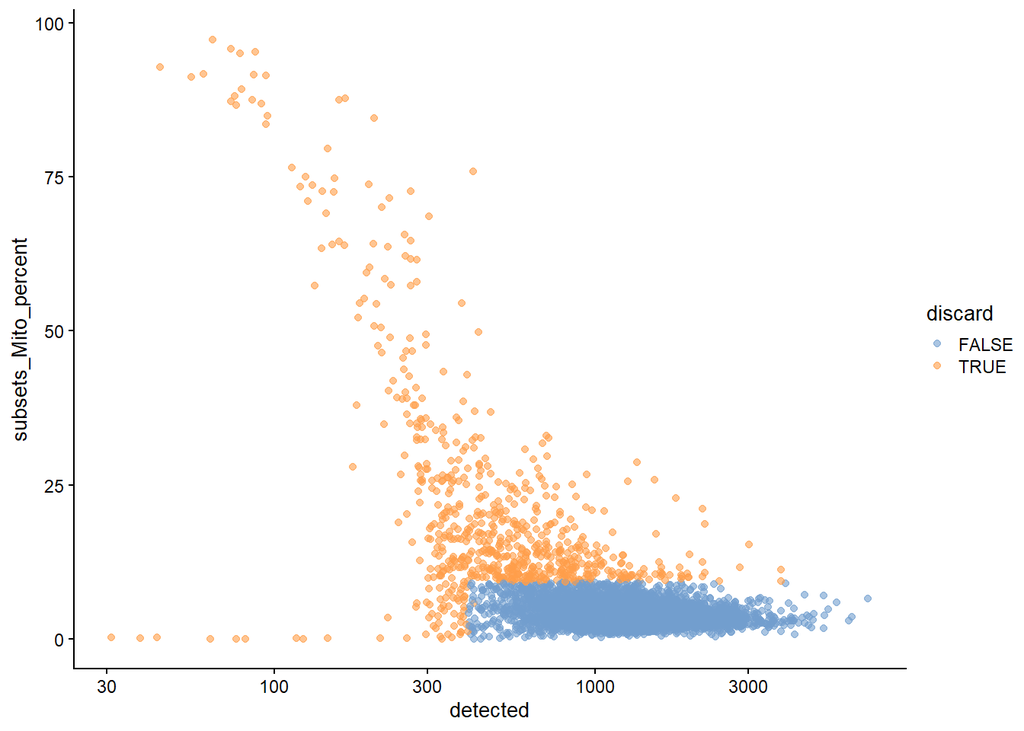

```r
plotColData(sce, x="detected", y="subsets_Mito_percent", colour_by = "discard") + scale_x_log10()
```

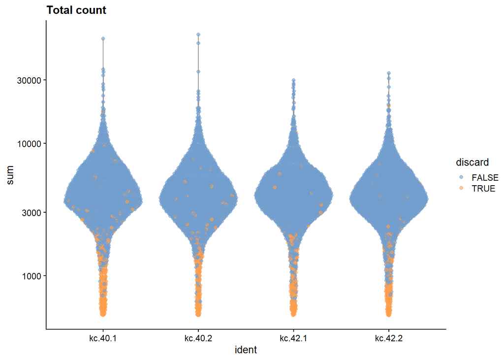

```r
plotColData(sce, x="ident", y="sum", colour_by="discard") +
        scale_y_log10() + ggtitle("Total count")
```

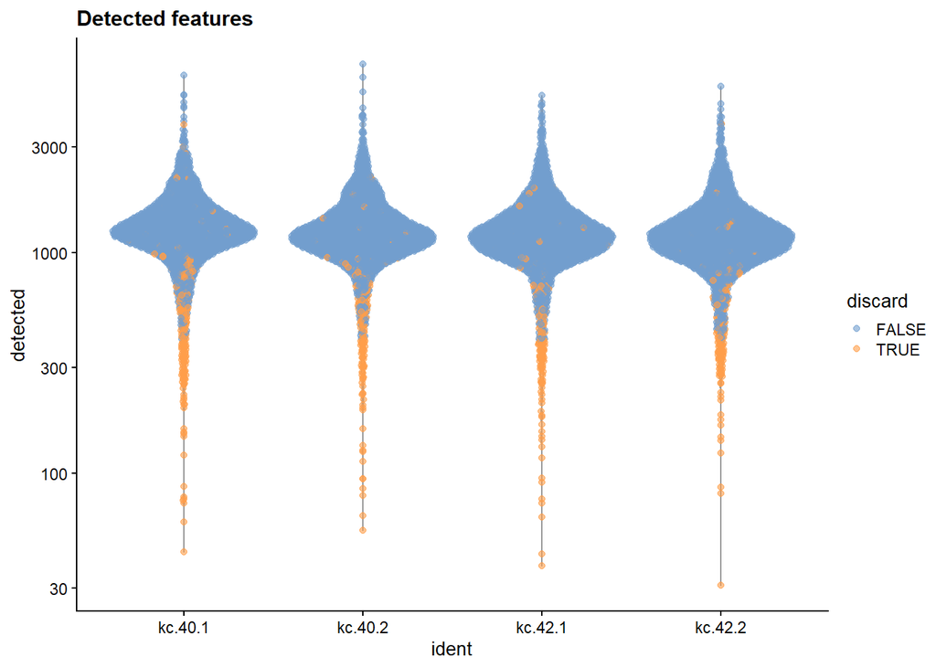

```r
plotColData(sce, x="ident", y="detected", colour_by="discard") +
        scale_y_log10() + ggtitle("Detected features")
```

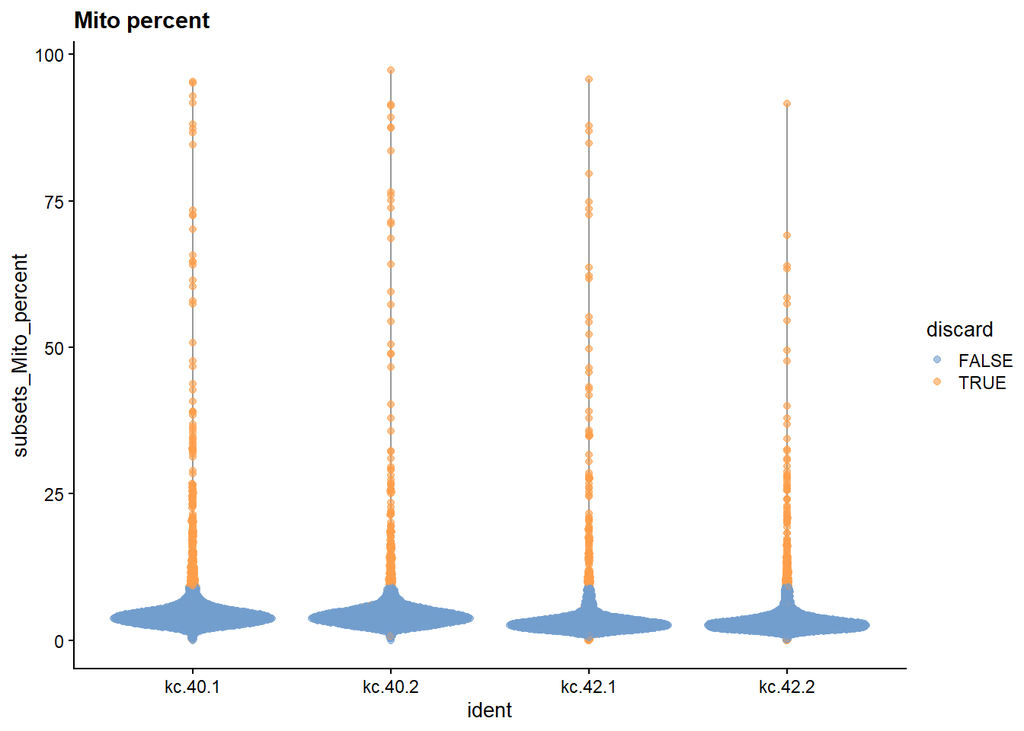

```r
plotColData(sce, x="ident", y="subsets_Mito_percent",
        colour_by="discard") + ggtitle("Mito percent")
```

Exploratory investigation of variance explained by metadata.

```r
#vars <- getVarianceExplained(logNormCounts(sce),
#    variables=c("ident", "subsets_Mito_percent", "sum", "detected"))
#plotExplanatoryVariables(vars)
```

Subset to QC-filtered cells.

```r
# Keeping the columns we DON'T want to discard.
filtered <- sce[,!discard]
dropped <- as.numeric(summary(discard)["TRUE"])
kept <- as.numeric(summary(discard)["FALSE"])
print(paste0(dropped, " cells were filtered, yielding ", kept, " remaining cells"))
```

```
## [1] "700 cells were filtered, yielding 9642 remaining cells"
```

Identify if a rare cell type might have been discarded.

```r
lost <- calculateAverage(counts(sce)[,!discard])
kept <- calculateAverage(counts(sce)[,discard])

logged <- edgeR::cpm(cbind(lost, kept), log=TRUE, prior.count=2)
logFC <- logged[,1] - logged[,2]
abundance <- rowMeans(logged)
```

Blue points are mitochondrial genes and are expected to be downregulated. Exclusion of a cell type may be indicated by overexpression on this plot, of which there does not appear to be strong overexpression.

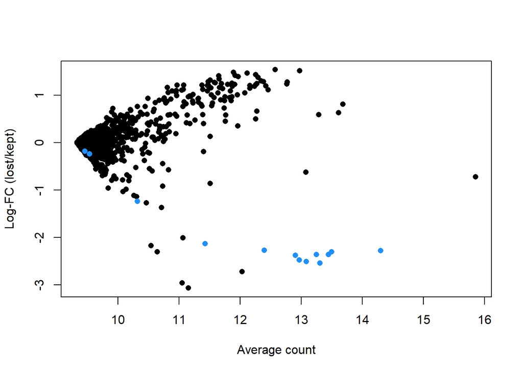

```r
plot(abundance, logFC, xlab="Average count", ylab="Log-FC (lost/kept)", pch=16)
points(abundance[is.mito], logFC[is.mito], col="dodgerblue", pch=16)
```

Even at NMAD = 4, CSH1 is differentially underexpressed, indicates omission of syncytiotrophoblasts, possibly correct since syncytiotrophoblast may have been differentially technically less sound.

```r
# Pull out differentially regulated genes
logFC[logFC < -2]
```

```
##      SPP1       HBB      HBG2      HBA2      HBA1      CSH1    MT-ND1    MT-ND2
## -2.008189 -3.069642 -2.171832 -2.964171 -2.308328 -2.722132 -2.273781 -2.511164
##    MT-CO1    MT-CO2   MT-ATP6    MT-CO3    MT-ND3    MT-ND4    MT-ND5    MT-CYB
## -2.283729 -2.304820 -2.475175 -2.362369 -2.544949 -2.361372 -2.134825 -2.377607
```

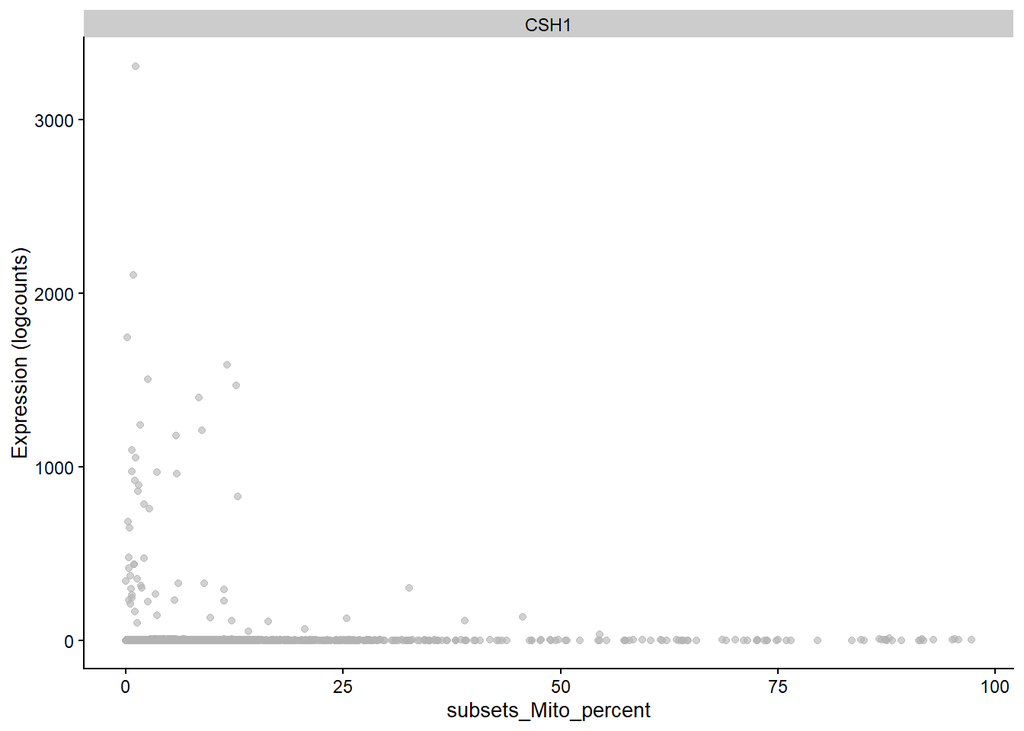

```r
plotExpression(sce, features = "CSH1", x = "subsets_Mito_percent")
```

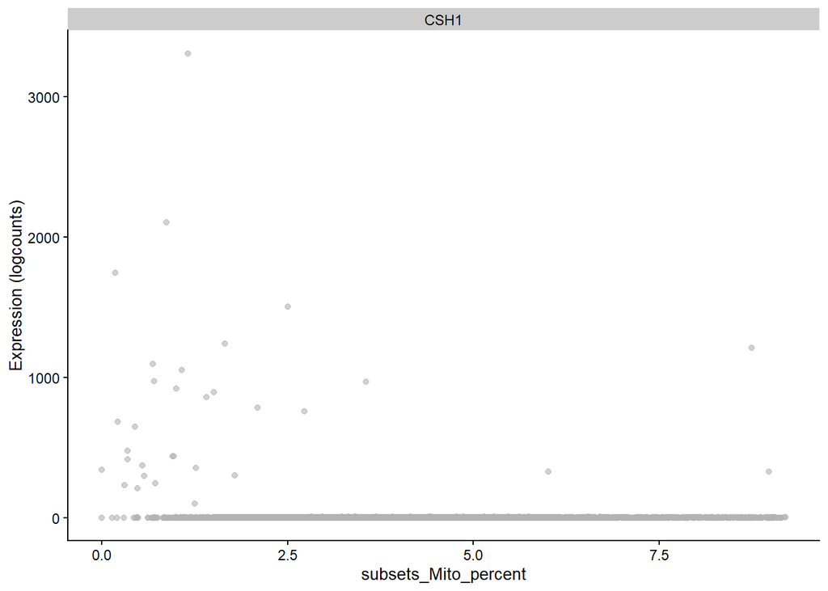

```r
plotExpression(filtered, features = "CSH1", x = "subsets_Mito_percent")
```

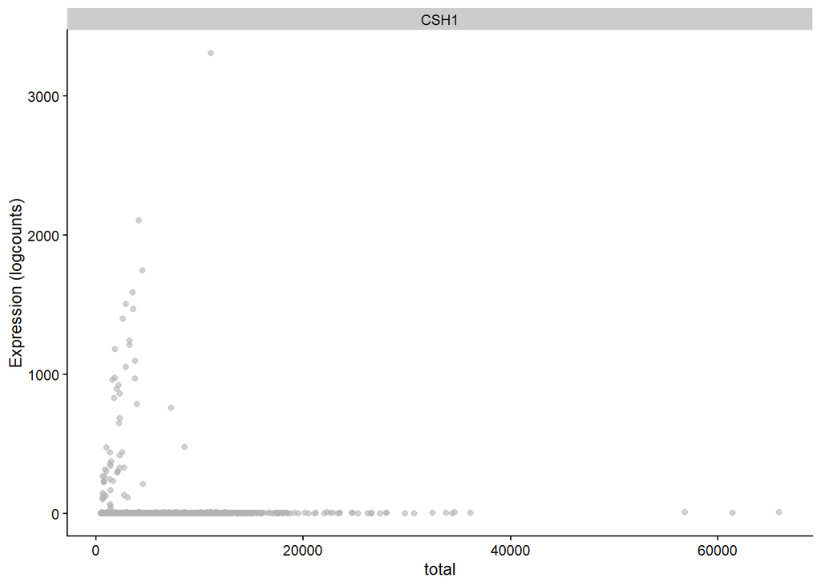

```r
plotExpression(sce, features = "CSH1", x = "total")
```

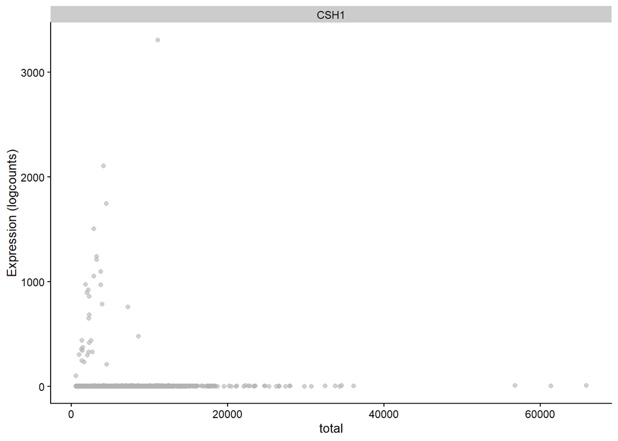

```r
plotExpression(filtered, features = "CSH1", x = "total")
```

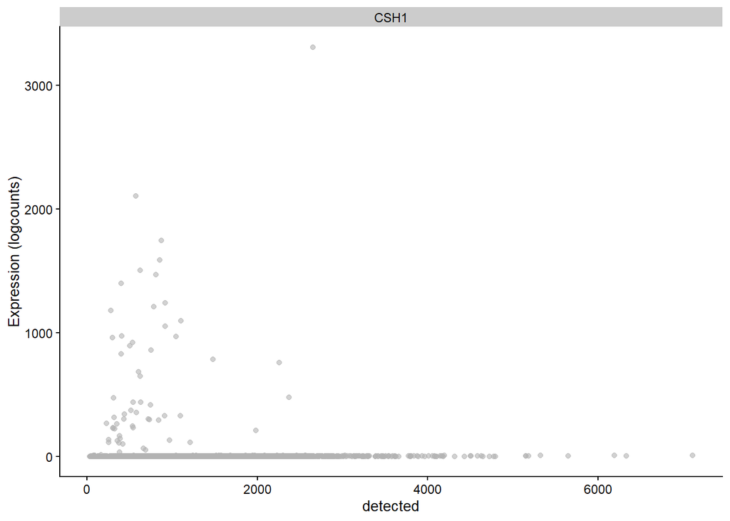

```r
plotExpression(sce, features = "CSH1", x = "detected")
```

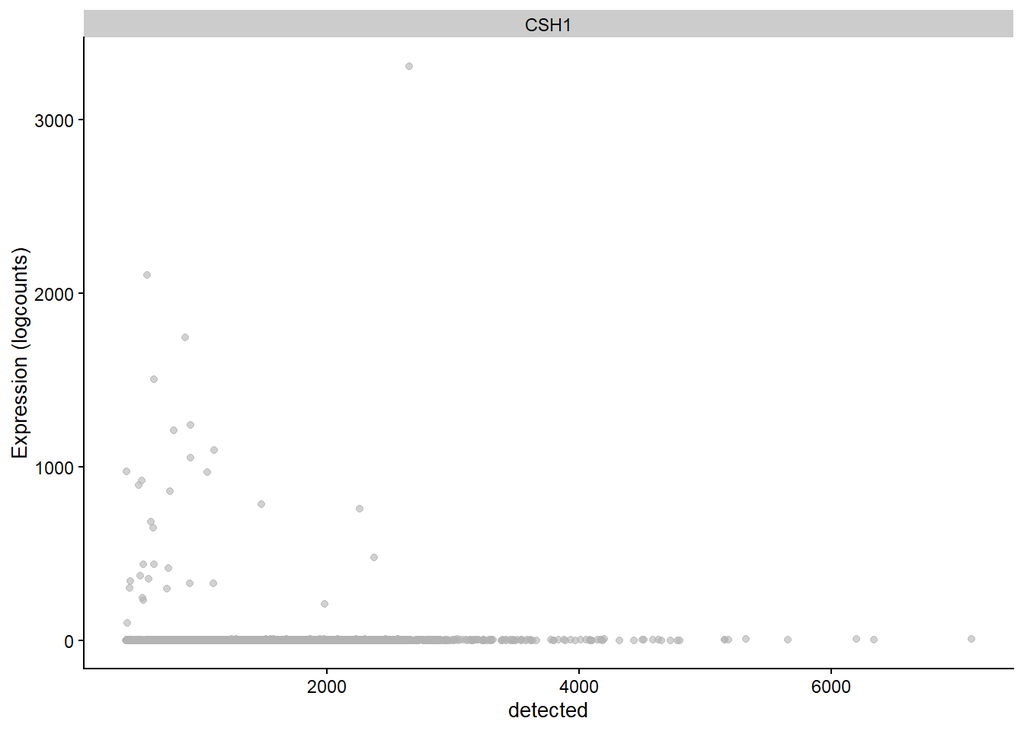

```r
plotExpression(filtered, features = "CSH1", x = "detected")
```

Convert to Seurat object for further preprocessing and analysis and save.

```r
kc <- as.Seurat(filtered)
#saveRDS(kc, paste0(data_dir, "placenta_scRNA_seq_kc_filtered_", Sys.Date(), ".rda"))
```

Explore batch effect in KC samples. There doesn’t appear to be much of a batch effect.

```r
# Should normalize and find variable features in each dataset separately
kc <- NormalizeData(object = kc, normalization.method = "LogNormalize", scale.factor = 10000)
kc <- FindVariableFeatures(object = kc)
kc <- ScaleData(kc)
kc <- RunPCA(kc, features = VariableFeatures(object = kc))
```

```
## PC_ 1
## Positive:  TMSB4X, CRIP1, SRGN, CD74, LTB, TRBC2, CD69, CST7, CTSW, CCR7
##     NKG7, IL7R, TRBC1, TRAC, CCL5, HLA-DPB1, HLA-DPA1, HLA-DRB1, HLA-DQB1, KLRB1
##     CD79A, GZMA, PRF1, IL32, FTH1, RGS1, IGHM, GPR183, GZMB, CD3G
## Negative:  COL3A1, EGFL6, COL6A1, CTHRC1, GPC3, COL1A1, PDPN, LUM, SPARC, DCN
##     ENPP1, CALD1, NDN, TCF21, APOD, COL1A2, MEG3, SOD3, DLK1, GJA1
##     MATN2, BMP5, WNT2, HSD17B2, ADAMTS1, MMP2, SERPINE2, C7, SRPX, IGFBP3
## PC_ 2
## Positive:  NPM1, LTB, TRBC2, IL32, IL7R, LDHB, TRBC1, CCR7, CTSW, TRAC
##     CD69, CST7, CCL5, NKG7, HMGB1, GZMA, KLRB1, ITM2A, CD3G, CD79A
##     LIME1, PRF1, RGS1, C12orf75, CD8A, GZMH, IGHM, KLRD1, HIST1H4C, GZMB
## Negative:  LYZ, CST3, PLAUR, FCN1, LST1, SERPINA1, CSTA, S100A9, IFI30, FTL
##     SOD2, CD68, TYROBP, S100A8, MAFB, AIF1, FCER1G, CTSS, C5AR1, IL1B
##     NAMPT, TYMP, PPIF, TIMP1, BCL2A1, SPI1, CEBPB, PSAP, IER3, G0S2
## PC_ 3
## Positive:  S100A12, S100A4, S100A6, VCAN, S100A8, FCN1, TIMP1, S100A10, CSTA, G0S2
##     VIM, AQP9, LYZ, PHLDA1, CFP, ANPEP, PPIF, CD300E, AC020656.1, CRIP1
##     BASP1, LUCAT1, CSF3R, TREM1, LGALS2, IL1B, THBS1, SMIM25, LGALS1, CCL20
## Negative:  RNASE1, C1QC, LYVE1, C1QA, PLTP, C1QB, LGMN, FOLR2, DAB2, MRC1
##     F13A1, VSIG4, MS4A4A, SLCO2B1, SPP1, CSF1R, STAB1, SELENOP, A2M, LILRB5
##     GPR34, CD163, HPGDS, HSPA1A, EGFL7, RHOB, NRP1, PDGFB, COLEC12, IGF1
## PC_ 4
## Positive:  CD79A, IGHM, IGHD, HLA-DQB1, HLA-DRA, TNFRSF13C, MS4A1, HLA-DQA1, HLA-DRB1, LINC00926
##     CD74, HLA-DPA1, HLA-DPB1, IGKC, SPIB, LY9, RUBCNL, FCER2, BCL11A, VPREB3
##     HLA-DMA, LINC01781, ADAM28, IGLC2, HLA-DMB, LTB, JCHAIN, IGLC3, TCL1A, TSPAN13
## Negative:  NKG7, CST7, CTSW, PRF1, GZMA, GZMB, CCL5, KLRB1, GZMH, KLRD1
##     GNLY, FGFBP2, ID2, SPON2, KLRF1, HOPX, SRGN, CLIC3, TMSB4X, IL2RB
##     CMC1, TRBC1, FCGR3A, GAPDH, CCL4, C12orf75, IL32, PFN1, LAIR2, KLRC1
## PC_ 5
## Positive:  C1QC, C1QA, FOLR2, LYVE1, C1QB, SELENOP, MRC1, F13A1, LGMN, VSIG4
##     PLTP, SLCO2B1, MS4A4A, SPP1, PMP22, C2, CSF1R, GAS6, TMEM176B, LILRB5
##     CD163, HPGDS, GPR34, DAB2, ENPP2, TMEM176A, MAF, STAB1, COLEC12, HSPA1A
## Negative:  CAV1, CDH5, CD34, RAMP2, GNG11, ESAM, IFI27, JAM2, TM4SF1, SPARCL1
##     VWF, ECSCR, PCAT19, ACVRL1, KDR, FCGR2B, TFPI2, ARHGAP29, SLC2A1, ADCY4
##     PLVAP, COL4A1, TINAGL1, APLNR, MMRN2, PECAM1, EGFL7, EPAS1, CAVIN1, PTPRB
```

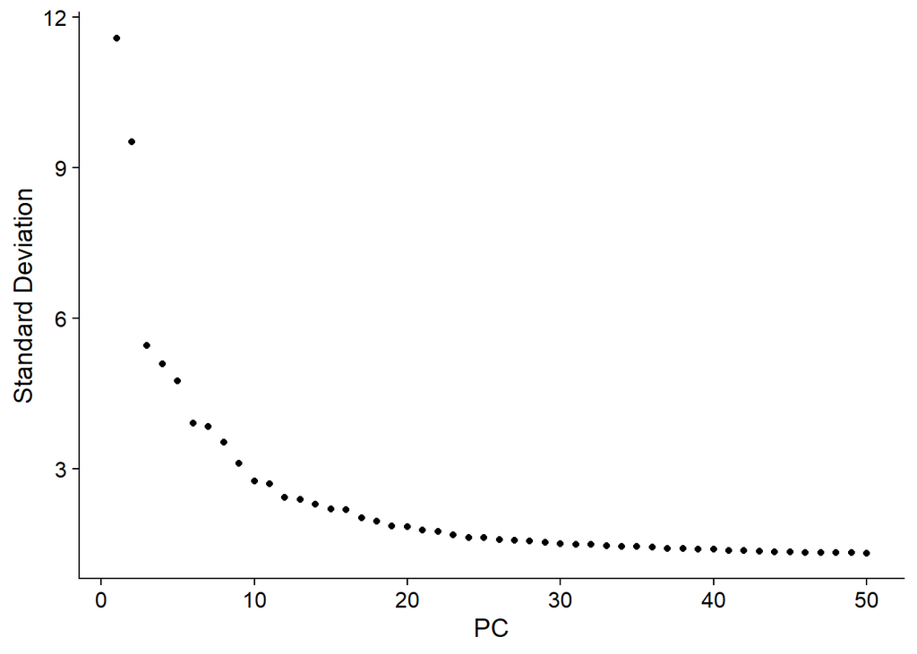

```r
ElbowPlot(object = kc, ndims = 100)
```

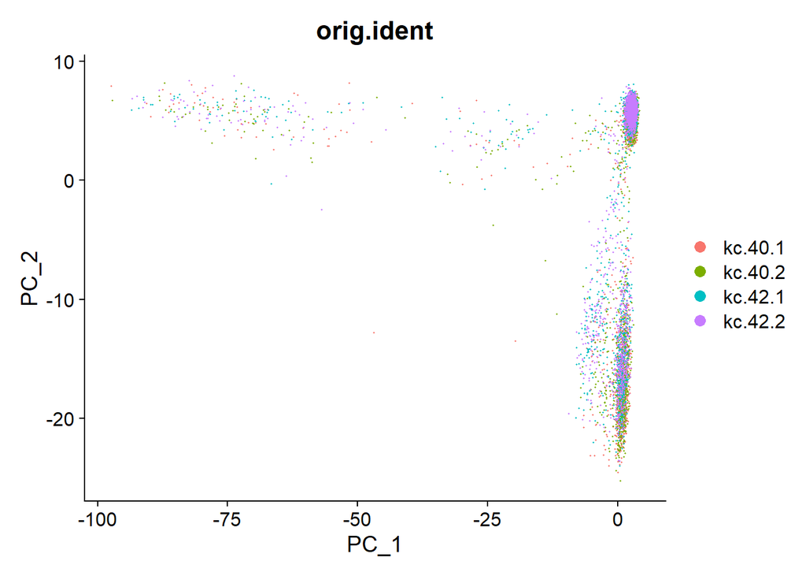

```r
DimPlot(kc, reduction = "pca", group.by = 'orig.ident')
```

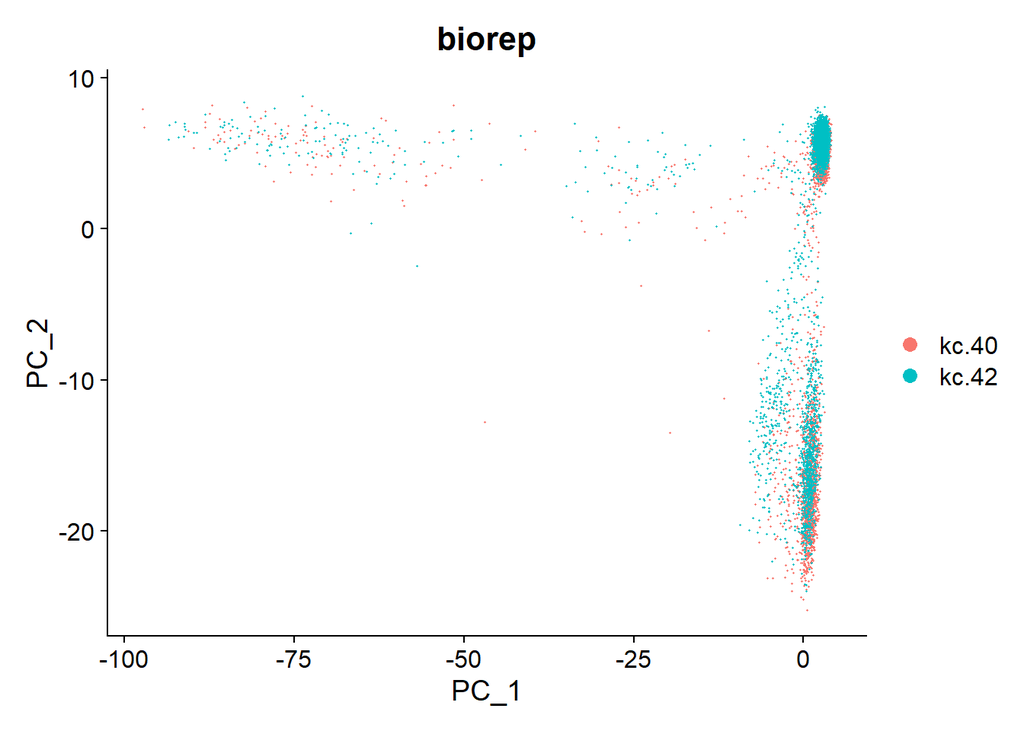

```r
DimPlot(kc, reduction = "pca", group.by = 'biorep')
```

```r
# Rename Samples KC_40_1 and KC_40_2 have been renamed 1A and 1B; KC_42_1 and KC_42_2 <- 2A and 2B.
#levels(All@active.ident) <- c("Placenta 1A", "Placenta 1B", "Placenta 2A", "Placenta 2B")
```

# Pique-Regi data QC

```r
# Convert to SingleCellExperiment for QC
sce.pr <- as.SingleCellExperiment(pr.seu)
# Factorize the batch variable
sce.pr$batch <- as.factor(sce.pr$batch)
# Clean-up memory
# rm(seu)
```

## Droplet Calling

Skipping droplet calling since 10x already filters that under Cell Ranger 4.0 based on Aaron Lun’s EmptyDroplets().

## Calculate QC Metrics

Deafult NMAD of 3.0 looks too restrictive for KC data but looks fine for PR data.

```r
# Find mitochondrial genes
is.mito <- grepl("^MT-", rownames(sce.pr))
# Add per cell QC metrics to the object
sce.pr <- addPerCellQC(sce.pr, subsets = list(Mito=is.mito))

# Create QC data frame
qc.df <- perCellQCMetrics(sce.pr, subsets = list(Mito=is.mito))
# Reasons for exclusion, considering batch
batch.reasons <- quickPerCellQC(qc.df,
                                sub.fields = "subsets_Mito_percent",
                                nmads = 3) # default nmads is 3
colSums(as.matrix(batch.reasons))
```

```
##              low_lib_size            low_n_features high_subsets_Mito_percent
##                         0                        19                       679
##                   discard
##                       698
```

```r
# Add discard metadata to object
sce.pr$discard <- batch.reasons$discard
discard <- batch.reasons$discard
```

QC plots.

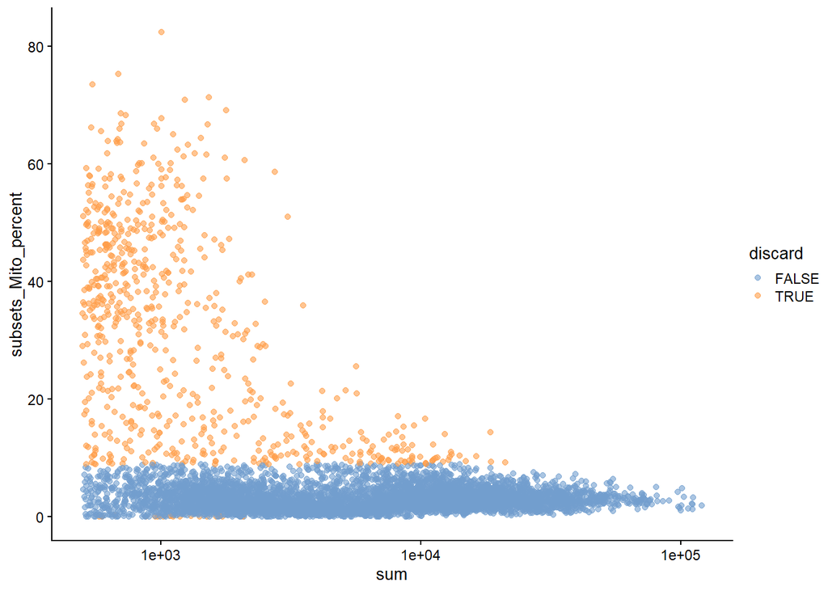

```r
plotColData(sce.pr, x="sum", y="subsets_Mito_percent", colour_by = "discard") + scale_x_log10()
```

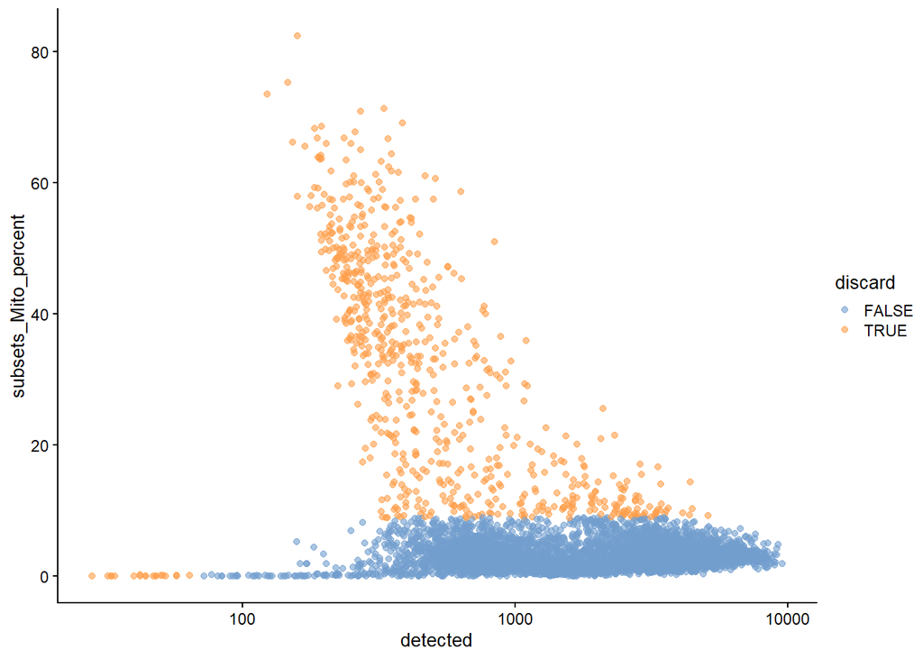

```r
plotColData(sce.pr, x="detected", y="subsets_Mito_percent", colour_by = "discard") + scale_x_log10()
```

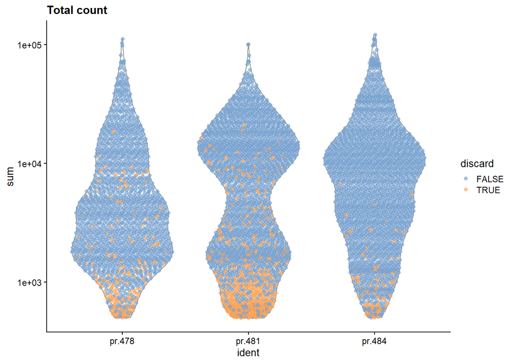

```r
plotColData(sce.pr, x="ident", y="sum", colour_by="discard") +
        scale_y_log10() + ggtitle("Total count")
```

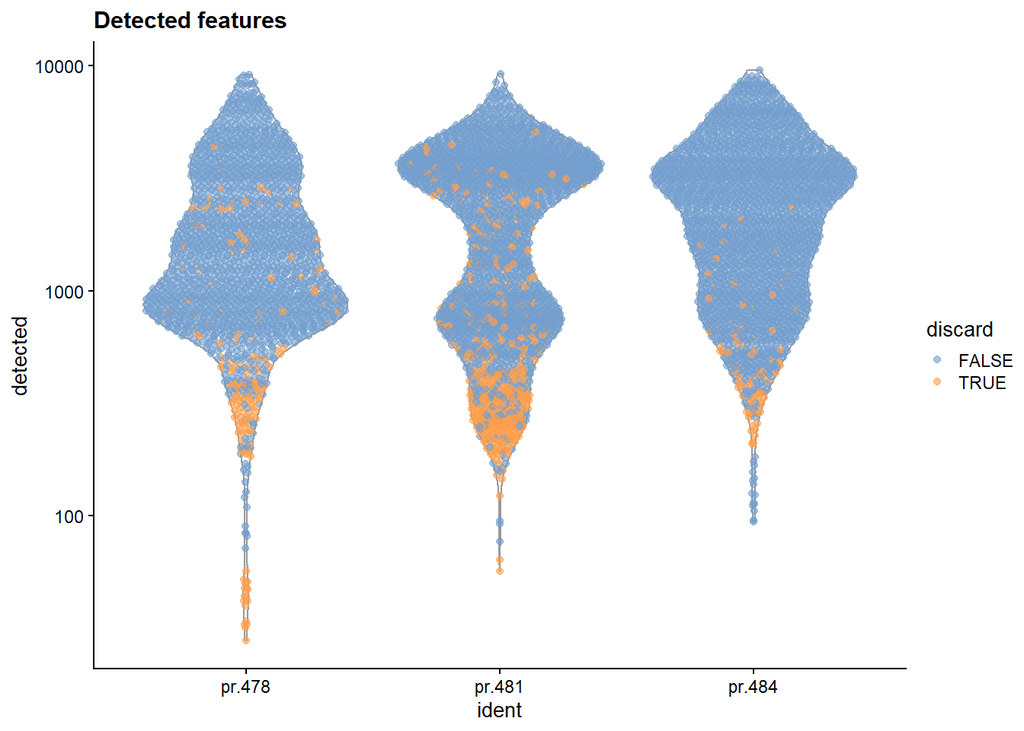

```r
plotColData(sce.pr, x="ident", y="detected", colour_by="discard") +
        scale_y_log10() + ggtitle("Detected features")
```

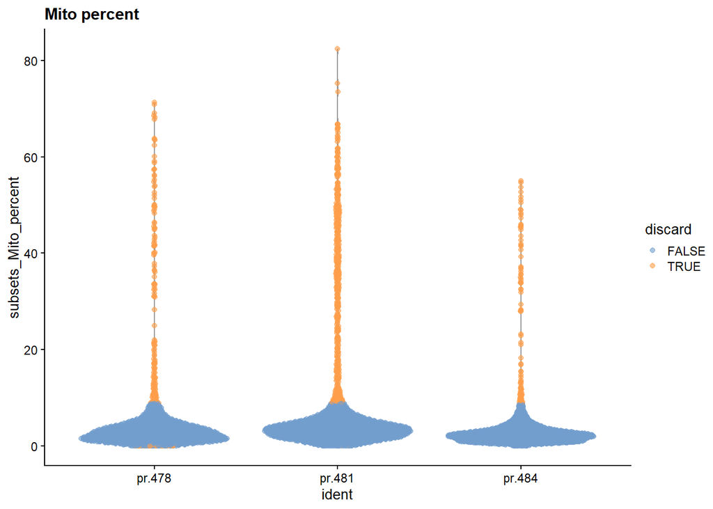

```r
plotColData(sce.pr, x="ident", y="subsets_Mito_percent",
        colour_by="discard") + ggtitle("Mito percent")
```

Exploratory investigation of variance explained by metadata.

```r
#vars <- getVarianceExplained(logNormCounts(sce.pr),
#    variables=c("ident", "subsets_Mito_percent", "sum", "detected"))
#plotExplanatoryVariables(vars)
```

Subset to QC-filtered cells.

```r
# Keeping the columns we DON'T want to discard.
filtered <- sce.pr[,!discard]
dropped <- as.numeric(summary(discard)["TRUE"])
kept <- as.numeric(summary(discard)["FALSE"])
print(paste0(dropped, " cells were filtered, yielding ", kept, " remaining cells"))
```

```
## [1] "698 cells were filtered, yielding 6313 remaining cells"
```

Identify if a rare cell type might have been discarded.

```r
lost <- calculateAverage(counts(sce.pr)[,!discard])
kept <- calculateAverage(counts(sce.pr)[,discard])

logged <- edgeR::cpm(cbind(lost, kept), log=TRUE, prior.count=2)
logFC <- logged[,1] - logged[,2]
abundance <- rowMeans(logged)
```

Blue points are mitochondrial genes and are expected to be downregulated. Exclusion of a cell type may be indicated by overexpression on this plot, of which there does not appear to be strong overexpression.

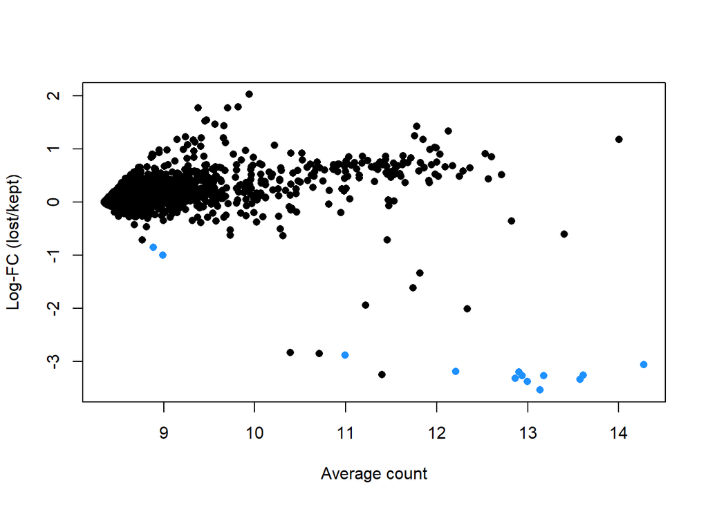

```r
plot(abundance, logFC, xlab="Average count", ylab="Log-FC (lost/kept)", pch=16)
points(abundance[is.mito], logFC[is.mito], col="dodgerblue", pch=16)
```

No clear cell types omitted based on my prior knowledge.

```r
logFC[logFC < -2]
```

```
## MTRNR2L12      HBG2  MTRNR2L8  MTRNR2L1    MT-ND1    MT-ND2    MT-CO1    MT-CO2
## -3.243873 -2.006484 -2.849604 -2.827602 -3.194164 -3.371292 -3.056090 -3.340338
##   MT-ATP6    MT-CO3    MT-ND3   MT-ND4L    MT-ND4    MT-ND5    MT-CYB
## -3.264296 -3.264840 -3.535530 -2.884203 -3.260817 -3.189200 -3.313182
```

Convert to Seurat object for further preprocessing and analysis and save.

```r
pr <- as.Seurat(filtered)
```

Explore batch effect in PR samples. There may be some batch effect.

```r
# Should normalize and find variable features in each dataset separately
pr <- NormalizeData(object = pr, normalization.method = "LogNormalize", scale.factor = 10000)
pr <- FindVariableFeatures(object = pr)
pr <- ScaleData(pr)
pr <- RunPCA(pr, features = VariableFeatures(object = pr))
```

```
## PC_ 1
## Positive:  DCN, EGFL6, LUM, DLK1, COL3A1, HGF, COL6A2, CXCL14, COL6A1, MEG3
##     CFD, PTGDS, RARRES2, TCF21, COL1A1, OLFML3, APOD, CTHRC1, TGFBI, SRPX
##     CADM3, IGFBP3, MFAP4, PDPN, COL1A2, ENPP1, WNT2, MMP2, SPARC, PMP22
## Negative:  KRT7, HMGA1, CLDN4, ISM2, KRT8, ERVH48-1, GGH, KRT18, MLLT1, SLC27A2
##     HSD17B1, SLC25A5, KRT19, VWA1, SLC13A3, SLC26A2, MT2A, HMGB3, MFAP5, FAM89A
##     KRT23, ANXA3, CRYBG1, HEXB, ADRB1, RMI2, TGM2, TFAP2C, CYP2J2, CCNE1
## PC_ 2
## Positive:  TYROBP, SRGN, LAPTM5, TMSB4X, CD74, FCER1G, CYBA, HCST, AIF1, FTL
##     HLA-DRA, CCL3, HLA-DRB1, LST1, C1QC, C1QA, CTSS, C1QB, CD37, CD53
##     ITGB2, CCL4, CORO1A, CD14, SPI1, HLA-DPA1, CD68, MS4A6A, SPP1, CD44
## Negative:  H19, TIMP3, FSTL1, CDKN1C, IL6ST, SERPINE2, EPAS1, KRT18, CCN1, FLT1
##     SPARC, HEXB, KRT8, COL4A1, ADAMTS1, ISM2, KRT19, IGF2, KRT7, BGN
##     SELENOM, EFEMP1, MFAP5, IGFBP3, FSTL3, HTRA1, LTBP1, NOTUM, GPC3, VGLL3
## PC_ 3
## Positive:  PAPPA, PAPPA2, EBI3, HLA-G, CORO6, LVRN, ASCL2, AOC1, COL17A1, TNFSF10
##     QSOX1, MCAM, CST6, LINC02246, ITGA5, SLCO2A1, HTRA4, FN1, NOTUM, DIO2
##     FSTL3, PLPP2, MYCNUT, CSF2RB, PRG2, AC211433.1, PYCR1, EGFR-AS1, NOG, TIMP2
## Negative:  EFEMP1, GGH, RPS4Y1, HMGN2, HMGB1, TYMS, HMGB2, PDLIM1, CDK1, CCNA2
##     LY6E, SLC27A2, NUSAP1, TOP2A, PBK, DEPDC1, MT2A, BIRC5, PRC1, CCNB2
##     PCLAF, UBE2C, MAD2L1, TK1, CENPF, MKI67, UBE2T, RMI2, SLC29A1, AURKB
## PC_ 4
## Positive:  CDK1, CCNA2, TOP2A, NUSAP1, MKI67, BIRC5, UBE2C, CD68, AURKB, PBK
##     DEPDC1, PRC1, TYMS, PCLAF, CENPF, HMMR, PLK1, NUF2, ANLN, SPC25
##     C1QC, TK1, CDKN3, AIF1, CDCA3, SPP1, TYROBP, CENPA, C1QA, MAD2L1
## Negative:  HSD17B1, GSTA3, INSL4, CYP19A1, PRKCZ, TMEM150A, MUC15, CGA, KLRB1, HOPX
##     LCMT1-AS2, SLC26A2, AC005532.1, TACC2, CRYBG1, NKG7, MLLT1, CD7, KISS1, RHOBTB1
##     CSHL1, CSH2, KRT23, CST7, HSPB8, SVEP1, CD3D, TRBC1, KLRD1, GH2
## PC_ 5
## Positive:  NKG7, KLRB1, CD7, CST7, KLRD1, CRIP1, CCL5, PLAC8, IL32, CD69
##     XCL2, GNLY, CTSW, IFNG, TRBC1, GZMA, SRGN, KLRC1, CYTIP, TSC22D3
##     KLRF1, TRBC2, MYADM, MARCKSL1, GZMB, CD3D, ADGRE5, CLEC2B, DOK2, XCL1
## Negative:  CTSB, C1QA, C1QC, C1QB, CTSD, PLTP, HSD17B1, RNASE1, SPP1, F13A1
##     CD14, SLC26A2, FOLR2, ITM2B, MS4A4A, VSIG4, STAB1, S100A9, LYVE1, INSL4
##     MLLT1, MS4A7, CSF1R, KRT23, AIF1, CD68, MS4A6A, PRKCZ, HMOX1, GSTA3
```

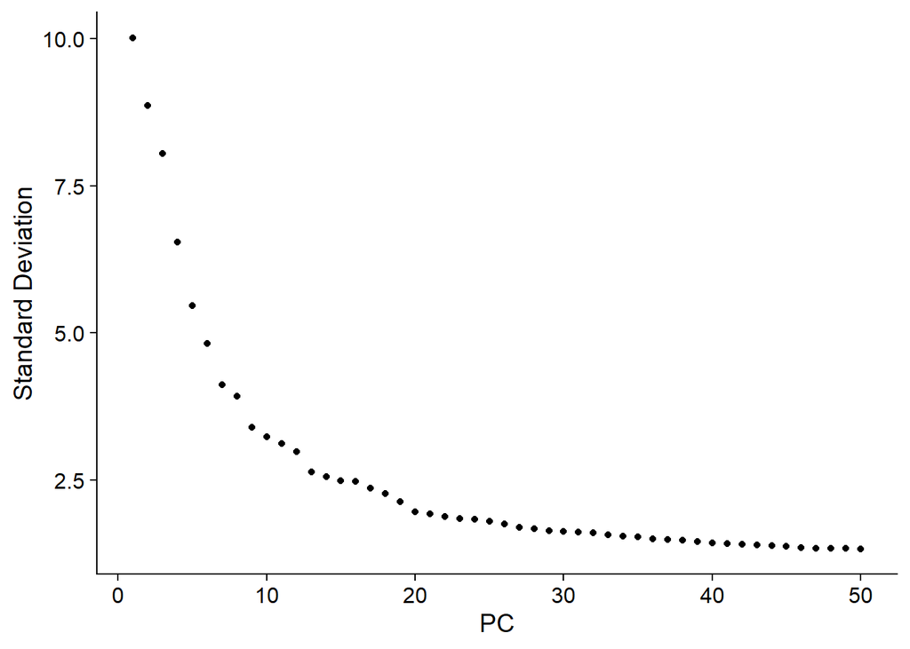

```r
ElbowPlot(object = pr, ndims = 100)
```

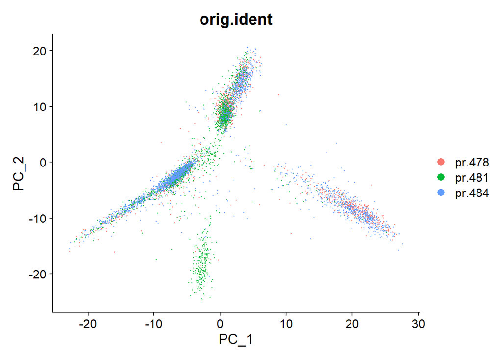

```r
DimPlot(pr, reduction = "pca", group.by = 'orig.ident')
```

## QC stats filtering reporting

```r
# cbind because cells are on columns and genes are on rows
sce.combined <- cbind(sce, sce.pr)
sce.combined$sample <- factor(sce.combined$ident, labels = LIBRARY.ID)
```

```r
sce.meta <- data.frame(
  LIBRARY.ID = sce.combined$sample,
  rna = sce.combined$sum,
  genes = sce.combined$detected,
  mito = sce.combined$subsets_Mito_percent,
  discard = sce.combined$discard
)

qc.supp <-
  sce.meta %>%
  group_by(LIBRARY.ID) %>%
  summarize(RNA.MOLECULES.MEDIAN = median(rna),
            RNA.MOLECULES.IQR = ceiling(iqr(rna)),
            GENES.MEDIAN = median(genes),
            GENES.IQR = ceiling(iqr(genes)),
            MITO.PERCENT.MEDIAN = round(median(mito), digits = 2),
            MITO.PERCENT.IQR = round(iqr(mito), digits = 2))
cell.count.post.filter <-
  sce.meta %>%
  group_by(LIBRARY.ID) %>%
  filter(discard == F) %>%
  tally()

qc.supp$CELL.COUNT <- cell.count.post.filter$n

qc.prefilter <- data.frame(LIBRARY.ID, FETAL.SEX, TOTAL.DROPLETS.RAW, TOTAL.RNA.RAW, TOTAL.GENES.RAW, TOTAL.CELLS, FETAL.MATERNAL.DOUBLETS.REMOVED)

QC <- left_join(qc.prefilter, qc.supp)
colnames(QC) <- c("Sample", "Fetal Sex", "Droplets Sequenced", "Total Unique RNA Molecules", "Total Unique Genes Detected", "Total Cells", "Maternal/Fetal Doublets Removed", "Unique RNA Molecules, Median", "Unique RNA Molecules, IQR", "Unique Genes, Median", "Unique Genes, IQR", "Percent Mitochondrial Gene Expression, Median", "Percent Mitochondrial Gene Expression, IQR", "Cells in Final Analytic Sample")

#write.table(x = QC, file = here("results", "single_cell_qc", "scrna_qc_summary.csv"), row.names = F, sep = ",")
```

```r
base.size <- 24

rna.vln <- plotColData(sce.combined, x="sample", y="sum", colour_by="discard") +
        scale_y_log10() + ggtitle("Total RNA molecules") + theme_bw(base_size = base.size) +
        theme(legend.position = "bottom") +
        guides(colour = guide_legend(override.aes = list(size=20), reverse = TRUE))


#ggsave(here("results", "single_cell_qc", paste0(Sys.Date(), "rna_molecules_by_rep.png")))
gene.vln <- plotColData(sce.combined, x="sample", y="detected", colour_by="discard") +
        scale_y_log10() + ggtitle("Detected genes") + theme_bw(base_size = base.size)
#ggsave(here("results", "single_cell_qc", paste0(Sys.Date(), "genes_detected_by_rep.png")))
mito.vln <- plotColData(sce.combined, x="sample", y="subsets_Mito_percent",
        colour_by="discard") + ggtitle("% Mitochondrial genes") + ylab("percentage") + theme_bw(base_size = base.size)
#ggsave(here("results", "single_cell_qc", paste0(Sys.Date(), "percent_mito_by_rep.png")))

legend <- get_legend(rna.vln)
```

```r
panel <- ggarrange(rna.vln, gene.vln, mito.vln, ncol = 3, nrow = 1, labels = "AUTO", font.label = list(size = 40, face = "bold", color = "black"), common.legend = TRUE, legend = "bottom", legend.grob = legend)
#ggexport(panel, filename = here("results", "single_cell_qc", paste0(Sys.Date(), "_qc_vlns.png")), width = 1980, height = 1080)
```

# TODO

Clean-up merged object, looks like merging causes duplicate metadata columns

```r
merged <- merge(kc, pr)
#saveRDS(merged, paste0(data_dir, "kc_pr_qc_merged_", Sys.Date(), ".rda"))
```